# Assignment_12

```python
import pandas as pd
import numpy as np
import seaborn as sns
```

```python
sales = pd.read_csv('Datasets/gameSales2016.csv', sep=',')
```

```python
sales.head()
```

|  | Name | Platform | Year_of_Release | Genre | Publisher | NA_Sales | EU_Sales | JP_Sales | Other_Sales | Global_Sales | Critic_Score | Critic_Count | User_Score | User_Count | Developer | Rating |
| --- | --- | --- | --- | --- | --- | --- | --- | --- | --- | --- | --- | --- | --- | --- | --- | --- |
| 0 | Wii Sports | Wii | 2006.0 | Sports | Nintendo | 41.36 | 28.96 | 3.77 | 8.45 | 82.53 | 76.0 | 51.0 | 8 | 322.0 | Nintendo | E |
| 1 | Super Mario Bros. | NES | 1985.0 | Platform | Nintendo | 29.08 | 3.58 | 6.81 | 0.77 | 40.24 | NaN | NaN | NaN | NaN | NaN | NaN |
| 2 | Mario Kart Wii | Wii | 2008.0 | Racing | Nintendo | 15.68 | 12.76 | 3.79 | 3.29 | 35.52 | 82.0 | 73.0 | 8.3 | 709.0 | Nintendo | E |
| 3 | Wii Sports Resort | Wii | 2009.0 | Sports | Nintendo | 15.61 | 10.93 | 3.28 | 2.95 | 32.77 | 80.0 | 73.0 | 8 | 192.0 | Nintendo | E |
| 4 | Pokemon Red/Pokemon Blue | GB | 1996.0 | Role-Playing | Nintendo | 11.27 | 8.89 | 10.22 | 1.00 | 31.37 | NaN | NaN | NaN | NaN | NaN | NaN |

## Platform category

```python
sales.groupby(by="Platform").mean()
```

| Platform | Year_of_Release | NA_Sales | EU_Sales | JP_Sales | Other_Sales | Global_Sales | Critic_Score | Critic_Count | User_Count |
| --- | --- | --- | --- | --- | --- | --- | --- | --- | --- |
| 2600 | 1982.137931 | 0.681203 | 0.041128 | 0.000000 | 0.006842 | 0.729925 | NaN | NaN | NaN |
| 3DO | 1994.666667 | 0.000000 | 0.000000 | 0.033333 | 0.000000 | 0.033333 | NaN | NaN | NaN |
| 3DS | 2013.126953 | 0.160558 | 0.118231 | 0.193596 | 0.025692 | 0.498250 | 67.101190 | 30.172619 | 92.189655 |
| DC | 1999.942308 | 0.104423 | 0.032500 | 0.164615 | 0.005192 | 0.307115 | 87.357143 | 17.642857 | 84.500000 |
| DS | 2008.190858 | 0.177821 | 0.087774 | 0.081585 | 0.027546 | 0.375046 | 63.761506 | 18.638773 | 30.550388 |
| GB | 1995.958763 | 1.166531 | 0.487959 | 0.868571 | 0.083673 | 2.606633 | NaN | NaN | NaN |
| GBA | 2003.210851 | 0.228151 | 0.091545 | 0.057579 | 0.009404 | 0.387470 | 67.372146 | 12.728311 | 22.964706 |
| GC | 2003.400369 | 0.240036 | 0.069622 | 0.038813 | 0.009317 | 0.358561 | 69.488839 | 19.698661 | 35.748634 |
| GEN | 1993.034483 | 0.725862 | 0.208621 | 0.093103 | 0.033448 | 1.061379 | NaN | NaN | NaN |
| GG | 1992.000000 | 0.000000 | 0.000000 | 0.040000 | 0.000000 | 0.040000 | NaN | NaN | NaN |
| N64 | 1998.531646 | 0.435799 | 0.128715 | 0.107273 | 0.013730 | 0.686144 | NaN | NaN | NaN |
| NES | 1987.153061 | 1.285102 | 0.215816 | 1.006633 | 0.054184 | 2.561939 | NaN | NaN | NaN |
| NG | 1994.500000 | 0.000000 | 0.000000 | 0.120000 | 0.000000 | 0.120000 | NaN | NaN | NaN |
| PC | 2008.914316 | 0.097053 | 0.146242 | 0.000175 | 0.022977 | 0.267248 | 75.928671 | 27.920280 | 615.300000 |
| PCFX | 1996.000000 | 0.000000 | 0.000000 | 0.030000 | 0.000000 | 0.030000 | NaN | NaN | NaN |
| PS | 1998.005882 | 0.281136 | 0.178454 | 0.116809 | 0.034177 | 0.610426 | 71.515000 | 10.415000 | 73.851852 |
| PS2 | 2004.583921 | 0.270171 | 0.157006 | 0.064415 | 0.089514 | 0.581046 | 68.727273 | 23.526965 | 43.663175 |
| PS3 | 2010.840735 | 0.295635 | 0.248152 | 0.060248 | 0.101938 | 0.705808 | 70.382927 | 33.901220 | 205.891676 |
| PS4 | 2015.150127 | 0.276692 | 0.359008 | 0.040712 | 0.123028 | 0.799567 | 72.091270 | 38.968254 | 518.155642 |
| PSP | 2008.731769 | 0.090298 | 0.055153 | 0.063507 | 0.034260 | 0.243424 | 67.424242 | 23.398268 | 30.422803 |
| PSV | 2014.146172 | 0.029120 | 0.030370 | 0.050764 | 0.014954 | 0.125278 | 70.791667 | 27.066667 | 96.335664 |
| SAT | 1996.028902 | 0.004162 | 0.003121 | 0.186474 | 0.000405 | 0.194162 | NaN | NaN | NaN |
| SCD | 1993.833333 | 0.166667 | 0.060000 | 0.075000 | 0.008333 | 0.311667 | NaN | NaN | NaN |
| SNES | 1993.845188 | 0.256192 | 0.079665 | 0.487657 | 0.013473 | 0.837029 | NaN | NaN | NaN |
| TG16 | 1995.000000 | 0.000000 | 0.000000 | 0.080000 | 0.000000 | 0.080000 | NaN | NaN | NaN |
| WS | 2000.000000 | 0.000000 | 0.000000 | 0.236667 | 0.000000 | 0.236667 | NaN | NaN | NaN |
| Wii | 2008.966563 | 0.376439 | 0.198644 | 0.052523 | 0.059902 | 0.687977 | 62.823932 | 21.247863 | 53.123214 |
| WiiU | 2013.659864 | 0.259184 | 0.170952 | 0.088503 | 0.040476 | 0.558912 | 70.733333 | 32.211111 | 223.810000 |
| X360 | 2009.880682 | 0.477393 | 0.214548 | 0.009849 | 0.067956 | 0.769913 | 68.616812 | 42.121179 | 187.156315 |
| XB | 2003.636364 | 0.226566 | 0.073968 | 0.001675 | 0.010583 | 0.313422 | 69.859310 | 26.371034 | 24.259386 |
| XOne | 2014.951417 | 0.377004 | 0.208866 | 0.001377 | 0.057773 | 0.645506 | 73.325444 | 24.414201 | 285.769231 |

*It's a bit hard to make a quick judgement when there is so much numerical data like this, but it seems like there are significant differences in most columns when it comes to platform*

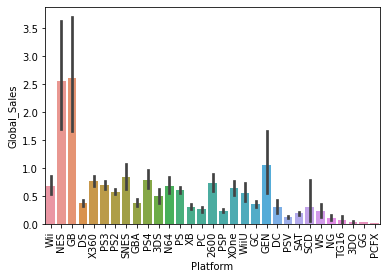

```python
barplot = sns.barplot(x="Platform", y="Global_Sales", data=sales)
barplot.set_xticklabels(barplot.get_xticklabels(), rotation=90);
```

*It looks like the NES and GB platforms have by far the most sales out of the rest. Most platforms sell roughly the same amount, with a few having more or less sales. There are definitely statistically significant differences between a number of platforms*

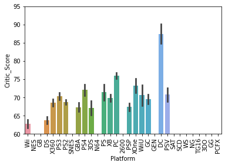

```python
barplot = sns.barplot(x="Platform", y="Critic_Score", data=sales)
barplot.set_xticklabels(barplot.get_xticklabels(), rotation=90)
barplot.set(ylim=(60, 95));
```

## Genre category

```python
sales.groupby(by="Genre").mean()
```

| Genre | Year_of_Release | NA_Sales | EU_Sales | JP_Sales | Other_Sales | Global_Sales | Critic_Score | Critic_Count | User_Count |
| --- | --- | --- | --- | --- | --- | --- | --- | --- | --- |
| Action | 2008.050181 | 0.260834 | 0.154045 | 0.047905 | 0.054777 | 0.517884 | 66.629101 | 27.780952 | 188.889617 |
| Adventure | 2008.263728 | 0.080783 | 0.048764 | 0.040138 | 0.012655 | 0.182417 | 65.331269 | 22.114551 | 103.410000 |
| Fighting | 2004.653524 | 0.263086 | 0.118174 | 0.103039 | 0.042827 | 0.527067 | 69.217604 | 27.909535 | 64.929825 |
| Misc | 2007.328298 | 0.232726 | 0.121566 | 0.061777 | 0.042509 | 0.458960 | 66.619503 | 21.533461 | 31.113895 |
| Platform | 2003.857631 | 0.501689 | 0.225619 | 0.147331 | 0.057534 | 0.932523 | 68.058350 | 23.698189 | 109.128505 |
| Puzzle | 2005.230228 | 0.211845 | 0.086224 | 0.098810 | 0.021345 | 0.419000 | 67.424107 | 20.308036 | 32.500000 |
| Racing | 2004.864600 | 0.287710 | 0.189359 | 0.045404 | 0.060929 | 0.583587 | 67.963612 | 23.028302 | 69.372855 |
| Role-Playing | 2007.130816 | 0.220540 | 0.125807 | 0.236973 | 0.039753 | 0.622933 | 72.652646 | 32.489824 | 320.746972 |
| Shooter | 2006.033179 | 0.447649 | 0.239864 | 0.029297 | 0.078692 | 0.795873 | 70.181144 | 35.610169 | 374.577922 |
| Simulation | 2006.663170 | 0.208455 | 0.129886 | 0.072998 | 0.035183 | 0.446705 | 68.619318 | 21.446023 | 82.656977 |
| Sports | 2005.503036 | 0.291495 | 0.160473 | 0.057726 | 0.057287 | 0.567291 | 71.968174 | 21.030151 | 41.567543 |
| Strategy | 2005.618128 | 0.100366 | 0.066135 | 0.072709 | 0.015886 | 0.255490 | 72.086093 | 28.271523 | 196.221865 |

*It seems like there are major differences in a couple of columns when it comes to genre*

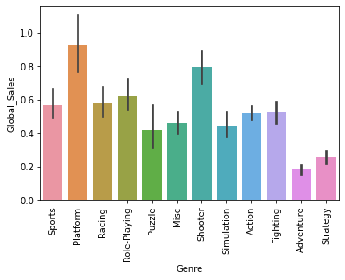

```python
barplot = sns.barplot(x="Genre", y="Global_Sales", data=sales)
barplot.set_xticklabels(barplot.get_xticklabels(), rotation=90);
```

*It seems like there are significant stastical differences between a couple of genres when it comes to global sales. Platformers and shooters differ the most*

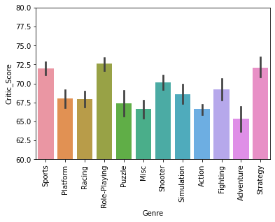

```python
barplot = sns.barplot(x="Genre", y="Critic_Score", data=sales)
barplot.set_xticklabels(barplot.get_xticklabels(), rotation=90)
barplot.set(ylim=(60, 80));
```

*It seems like there are significant stastical differences between a couple of genres when it comes to critic score. The sports, role-playing and strategy games seem to score better than games of other genres*